# Biostat M280 Homework 2

#### 7.5.3.1

1. Instead of summarising the conditional distribution with a boxplot, you could use a frequency polygon. What do you need to consider when using cut_width() vs cut_number()? How does that impact a visualisation of the 2d distribution of carat and price?
- Answer: cut_width() makes groups of width width; cut_number() makes n groups with (approximately) equal numbers of observations.

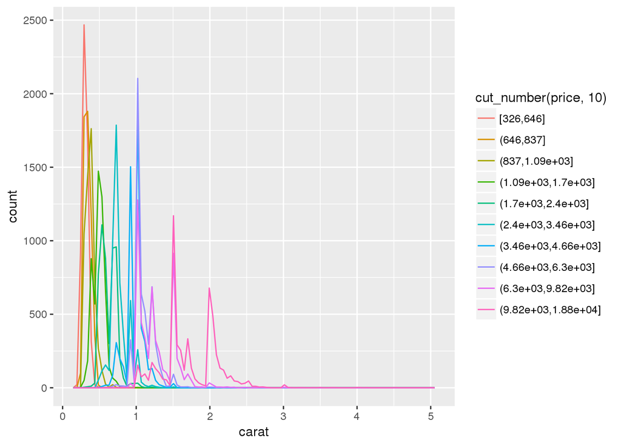

```r
# use cut_number
ggplot(data = diamonds, aes(x=carat, colour = cut_number(price, 10))) +
 geom_freqpoly(bins = 100)
```

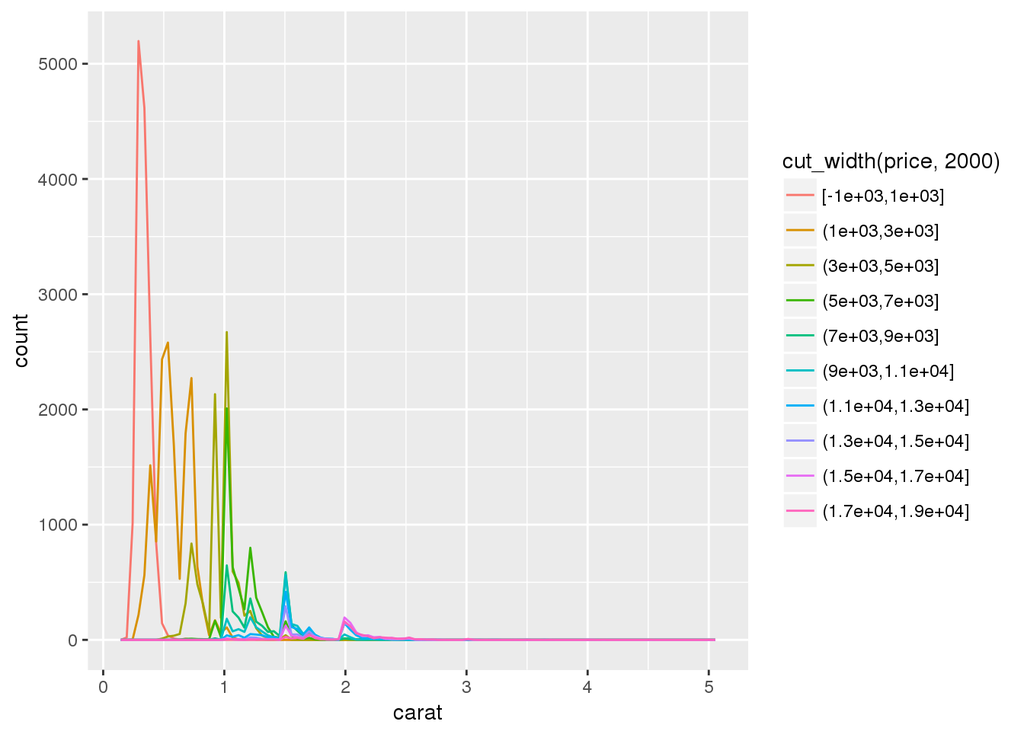

```r
# Use cut_width
ggplot(data = diamonds, aes(x=carat, colour = cut_width(price, 2000))) +
 geom_freqpoly(bins = 100)
```

2. Visualise the distribution of carat, partitioned by price.
- Use the cut_width() to make the plot partitioned by price.

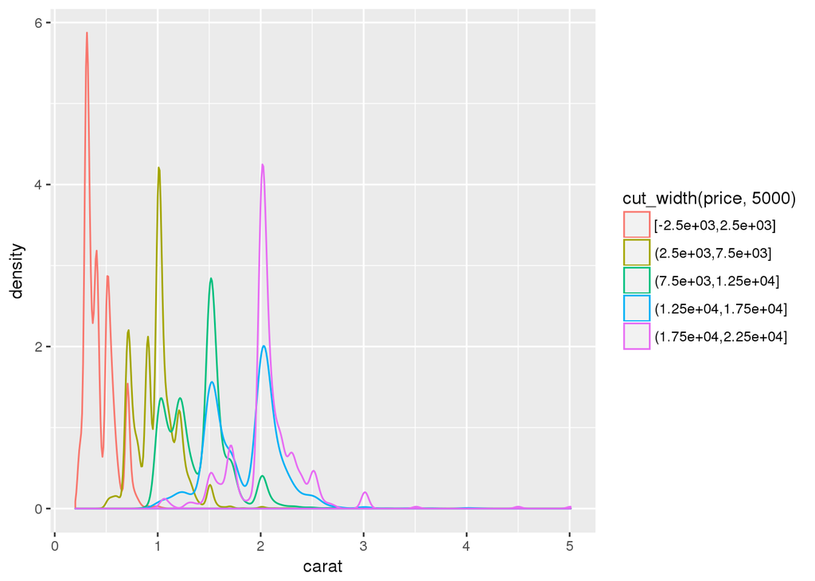

```r
ggplot(diamonds) +
  geom_density(mapping = aes(x = carat,
                             color = cut_width(price, 5000)))
```

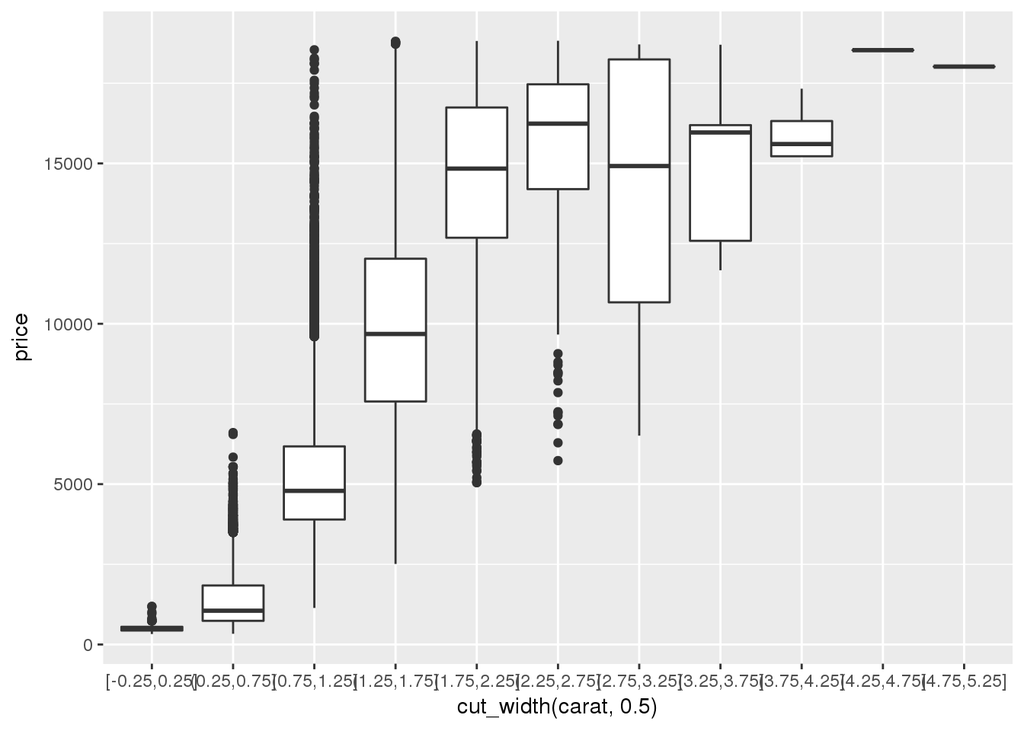

```r
ggplot(diamonds) +
geom_boxplot(mapping = aes(x = cut_width(carat, 0.5),
                             y = price))
```

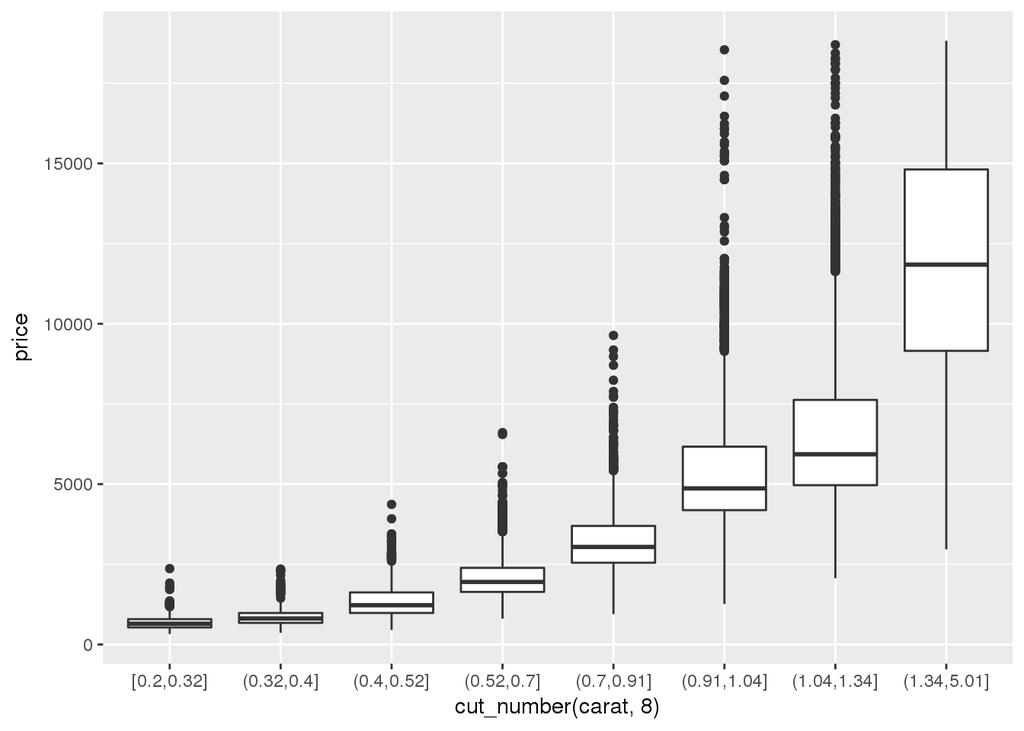

```r
ggplot(diamonds) +
geom_boxplot(mapping = aes(x = cut_number(carat, 8),
                             y = price))
```

```r
# I prefered use cut_number rather than cut_width, it showed clear pattern
```

- Answer: Use cut_width and cut_number to do the boxplot. As I expected, as the carat get large the price also get large. In addition, I found the larger the carat, the higher the variation for price (the possible reason for this is that the interval get bigger).
4. Combine two of the techniques you’ve learned to visualise the combined distribution of cut, carat, and price.

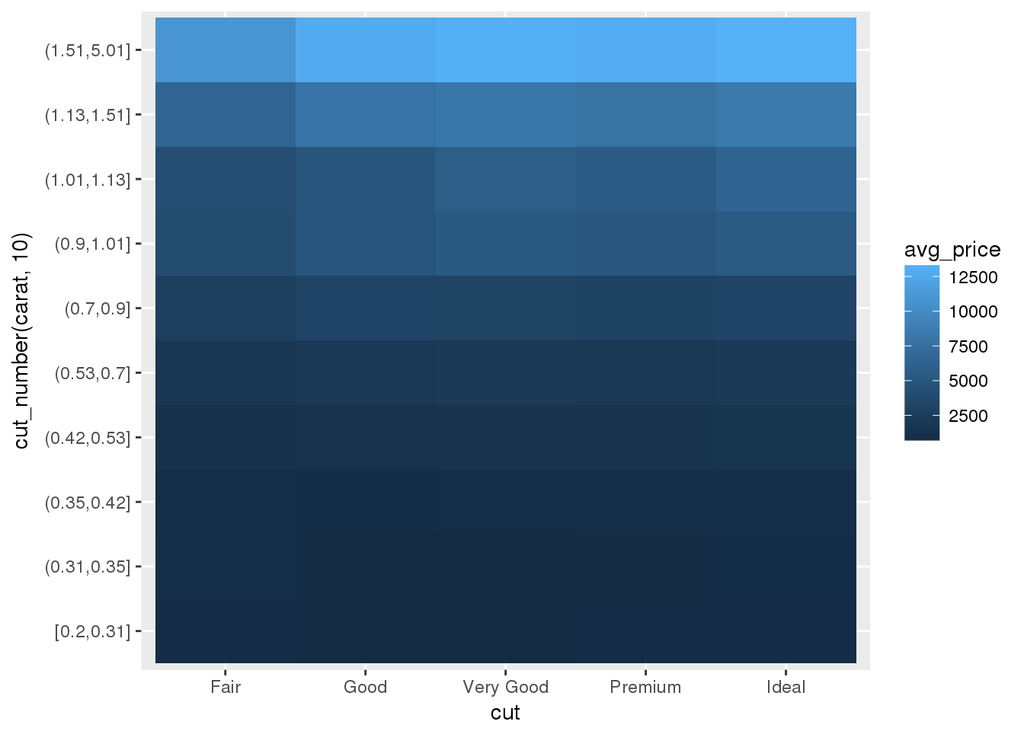

```r
# Use geom_tile to map the ave_price
diamonds %>%
        group_by(cut, cut_number(carat, 10)) %>%
        summarise(avg_price = mean(price, na.rm = TRUE)) %>%
        ggplot() +
        geom_tile(mapping = aes(x = cut, y = `cut_number(carat, 10)`, fill = avg_price))
```

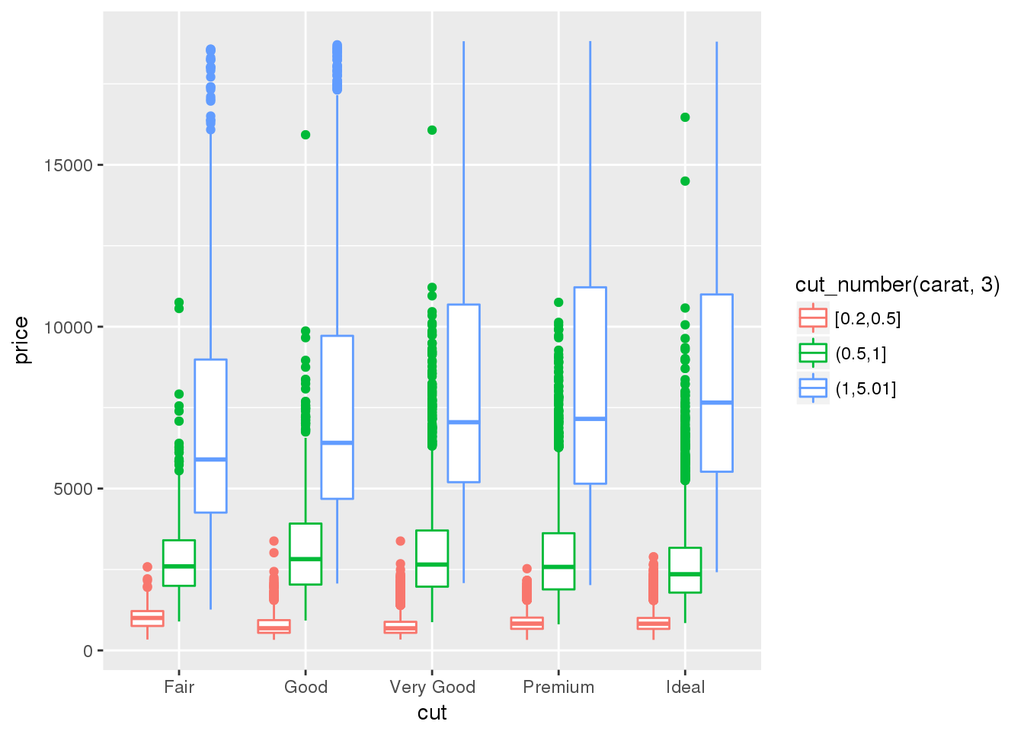

```r
# Use geom_boxplot()
ggplot(diamonds) +
  geom_boxplot(mapping = aes(x = cut, y = price,
                             color = cut_number(carat, 3)))
```

```r
# I prefer using this method it can show the relation more clear.
```

- The plot showed that overall better cut and larger carat, higher the price. Furthermore, The cut is not showed as strong influence on price as the carat.
5. Two dimensional plots reveal outliers that are not visible in one dimensional plots. For example, some points in the plot below have an unusual combination of x and y values, which makes the points outliers even though their x and y values appear normal when examined separately.

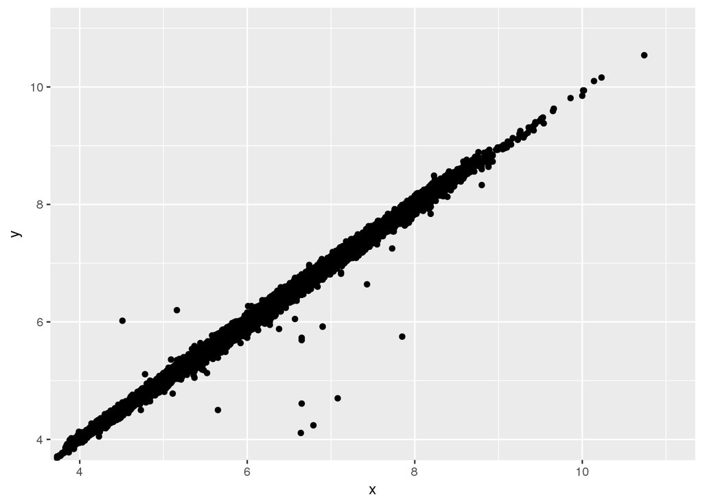

```r
ggplot(data = diamonds) +
  geom_point(mapping = aes(x = x, y = y)) +
  coord_cartesian(xlim = c(4, 11), ylim = c(4, 11))
```

- Why is a scatterplot a better display than a binned plot for this case?
- If we use the binned plot, the result showed as below:

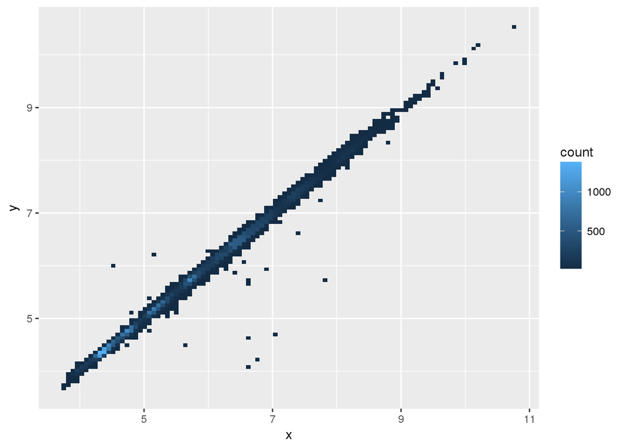

```r
ggplot(data = diamonds) +
  geom_bin2d(mapping = aes(x = x, y = y), bins = 100)
```

## Q2 (optional)

Read [Chapter 23](http://r4ds.had.co.nz/model-basics.html) (Model Basics) and [Chapter 24](http://r4ds.had.co.nz/model-building.html) (Model Building) of *R for Data Science* and do exercises 24.2.3 and 24.3.5.

## Q3

Redo HW1 Q2 using tidyverse. * Read in data

```r
library("tidyverse")
geno_data1 <- read_tsv("/home/m280-data/hw1/merge-geno.bim", col_names = F)
geno_data1 <- as_data_frame(geno_data1)
colnames(geno_data1) <- c("Chromosome","SNP_ID","Genetic_Distance","bp",
                       "Allele 1","Allele 2")
geno_data2 <- read_delim("/home/m280-data/hw1/merge-geno.fam"," ", col_names = F)
geno_data2 <- as_data_frame(geno_data2)
colnames(geno_data2) <- c("Family","Person","Father","Mother",
                       "Sex","Affection")
```

1. How many persons are in the data set (statisticians call this n)? How many SNPs are in the data set (statisticians call this p)?

```r
geno_data1 %>%
  count()
```

```
## # A tibble: 1 x 1
##         n
##     <int>
## 1 8348674
```

```r
geno_data2 %>%
  count()
```

```
## # A tibble: 1 x 1
##       n
##   <int>
## 1   959
```

- Answer: n = $959$ ; p = $8348674$.
2. Which chromosomes does this data set contain? How many SNPs are in each chromosome?

```r
geno_data1 %>%
  group_by(Chromosome) %>%
  summarise(n = n())
```

```
## # A tibble: 11 x 2
##    Chromosome       n
##         <int>   <int>
##  1          1 1309299
##  2          3 1215399
##  3          5 1090185
##  4          7  980944
##  5          9  732013
##  6         11  815860
##  7         13  602809
##  8         15  491208
##  9         17  477990
## 10         19  393615
## 11         21  239352
```

- Answer:

| $Chromesome$ | $SNPs$ |
| --- | --- |
| 1 | 1309299 |
| 3 | 1215399 |
| 5 | 1090185 |
| 7 | 980944 |
| 9 | 732013 |
| 11 | 815860 |
| 13 | 602809 |
| 15 | 491208 |
| 17 | 477990 |
| 19 | 393615 |
| 21 | 239352 |

3. MAP4 (microtubule-associated protein 4) is a gene on chromosome 3 spanning positions 47,892,180 bp – 48,130,769 bp. How many SNPs are located within MAP4 gene?

```r
filter(geno_data1, Chromosome == 3, bp >= 47892180, bp <= 48130769 ) %>%
  summarise(n = n())
```

```
## # A tibble: 1 x 1
##       n
##   <int>
## 1   894
```

- Answer: There are 894 SNPs located within MAP4 gene.
4. Reformat:
- Part 1:

```r
output_file <- "mendel1.txt"
fileConn <- file(output_file, open = "a")
writeLines("    2.40 = FILE FORMAT VERSION NUMBER", fileConn)
writeLines("8348674 = NUMBER OF SNPS LISTED HERE", fileConn)
close(fileConn)

mendel <- geno_data1[, c("SNP_ID", "Chromosome","bp")]
write_delim(mendel, output_file, delim = ",", col_names = FALSE, append = TRUE)
```

- Use the linux to check the result:

```bash
head mendel1.txt
```

```
##     2.40 = FILE FORMAT VERSION NUMBER
## 8348674 = NUMBER OF SNPS LISTED HERE
## 1-54490,1,54490
## 1-55550,1,55550
## 1-57033,1,57033
## 1-57064,1,57064
## 1-57818,1,57818
## 1-58432,1,58432
## 1-58448,1,58448
## 1-58814,1,58814
```

- Part 2:

```r
output_file <- "mendel2.txt"

mendel2 <- geno_data2 %>%
  mutate(Sex = replace(Sex, Sex == 1, "M")) %>%
  mutate(Sex = replace(Sex, Sex == 2, "F")) %>%
  mutate(Father = replace(Father, Father == "0", "")) %>%
  mutate(Mother = replace(Mother, Mother == "0", "")) %>%
  mutate(Affection = replace(Affection, Affection == 0, "")) %>%
  mutate(Person = str_replace(Person, "T2DG", "")) %>%
  mutate(Father = str_replace(Father, "T2DG", "")) %>%
  mutate(Mother = str_replace(Mother, "T2DG", ""))

write_delim(mendel2, output_file, delim = ",", col_names = FALSE)
```

- Use linux code to check the result:

```bash
head -20 mendel2.txt
```

```
## 2,0200001,,,M,
## 2,0200002,,,F,
## 2,0200003,,,F,
## 2,0200004,,,F,
## 2,0200005,,,M,
## 2,0200006,,,M,
## 2,0200007,,,F,
## 2,0200008,,,F,
## 2,0200009,,,F,
## 2,0200012,,,M,
## 2,0200013,,,M,
## 2,0200018,,,M,
## 2,0200023,,,F,
## 2,0200024,,,M,
## 2,0200027,,,F,
## 2,0200031,0200001,0200015,M,
## 2,0200032,0200001,0200015,F,
## 2,0200033,0200001,0200015,F,
## 2,0200034,0200001,0200015,F,
## 2,0200035,0200001,0200015,F,
```

## Q4 (optional)

Redo HW1 Q3 on Hoffman2, except now we want to submit each `runSum.R` job to a different node in the cluster.